# STAT/MATH 495: Problem Set 05

Jenn, Pei, and Anthony

2017-10-11

# Notes

We fit a linear model using dplyr, which we learned about [here](https://cran.r-project.org/web/packages/broom/vignettes/broom_and_dplyr.html).

# Exploratory Data Analysis

Information on the competition can be found [here](https://www.kaggle.com/c/bike-sharing-demand).

```r
# Storing a version of time in system time
train <- train %>% mutate(SysTime = as.numeric(unclass(datetime)))
test <- test %>% mutate(SysTime = as.numeric(unclass(datetime)))
```

Let’s look at our dependent variable: count, the total count of bikes rented during each hour.

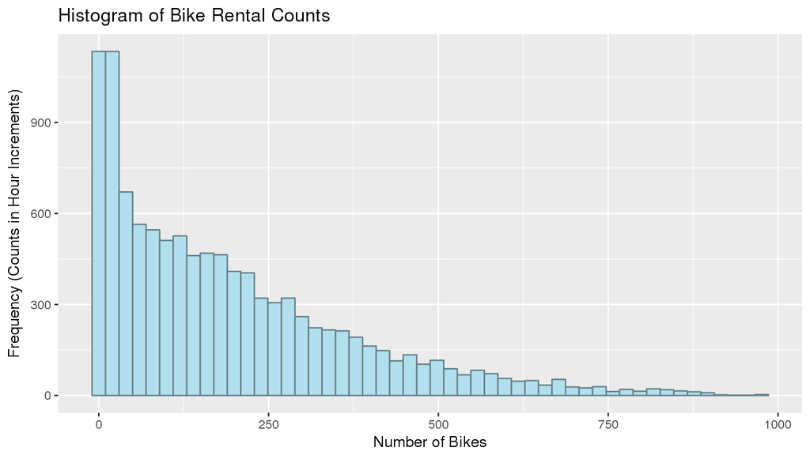

The histogram shows the distribution of bikes rented per hour has a right skew. We chose to log transform count as a potential fix.

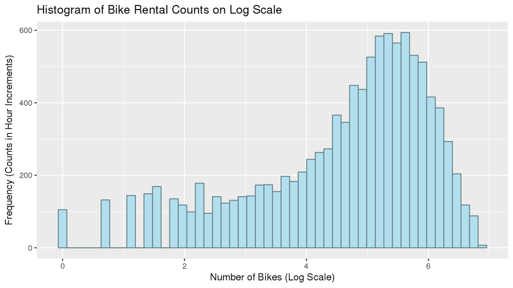

The histogram of log(count) shows a distribution that looks a bit closer to normal, although some left skew is still displayed. However, the more normal distribution of log(count) should result in better predictions when using linear regression.

Note: Since the logarithm of count is our outcome variable, we are interested in variables that have a high correlation with the `log_count`. We do not look at `registered` and `casual` because `count` is just the sum of these two variables.

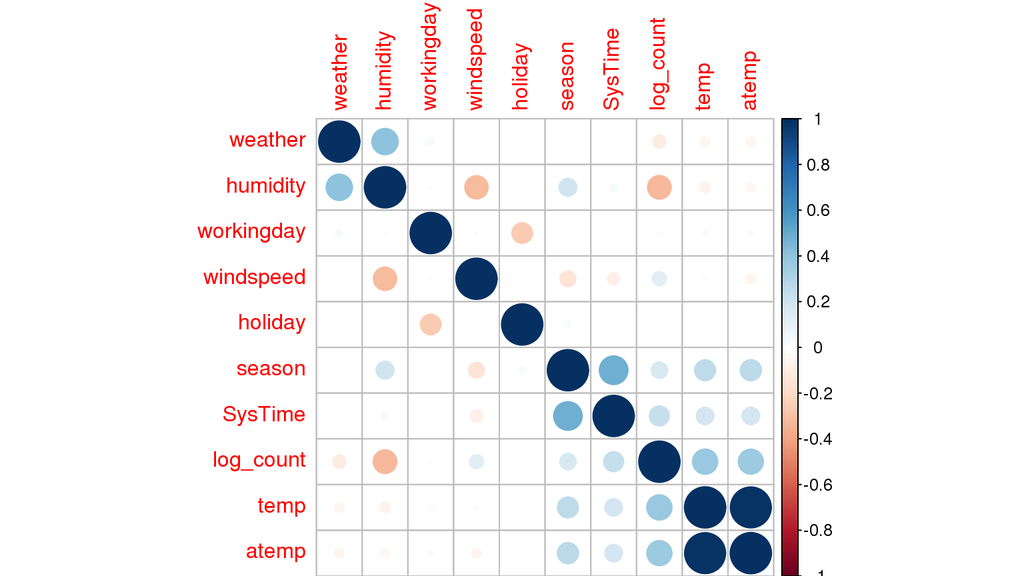

From the correlation plot, `atemp`, `dateTime` (`SysTime` in the plot), and `humidity` are the three variables that have the strongest relationship with bike rentals.

# Fitting the Model

Here, we fit a linear model for `log_count` predicted by the 3 most correlated variables: `atemp`, `dateTime`, and `humidity`.

```r
model <- lm(log_count ~ SysTime + atemp + humidity, data = train)
summary(model)$coefficients %>% knitr::kable(digits = 3)
```

|  | Estimate | Std. Error | t value | Pr(>\|t\|) |
| --- | --- | --- | --- | --- |
| (Intercept) | -15.540 | 0.899 | -17.280 | 0 |
| SysTime | 0.000 | 0.000 | 22.402 | 0 |
| atemp | 0.057 | 0.001 | 38.510 | 0 |
| humidity | -0.025 | 0.001 | -38.959 | 0 |

# Create Submission File

We now use our model to make predictions for the test set, taking the exponential of `log_count` to transform back to the original units of `count`.

```r
fit <- train %>% do(augment(lm(log_count ~ SysTime + atemp + humidity, data = .), newdata = test))
dfToSubmit <- fit %>% mutate(count = round(exp(.fitted), 0)) %>% select(datetime, count)

write.csv(dfToSubmit, file = "submission.csv", row.names = FALSE)
```

Sanity check: let’s look at the distribution of our predictions. It looks very similar to the distribution of the training set - skewed right and centered close to 0.

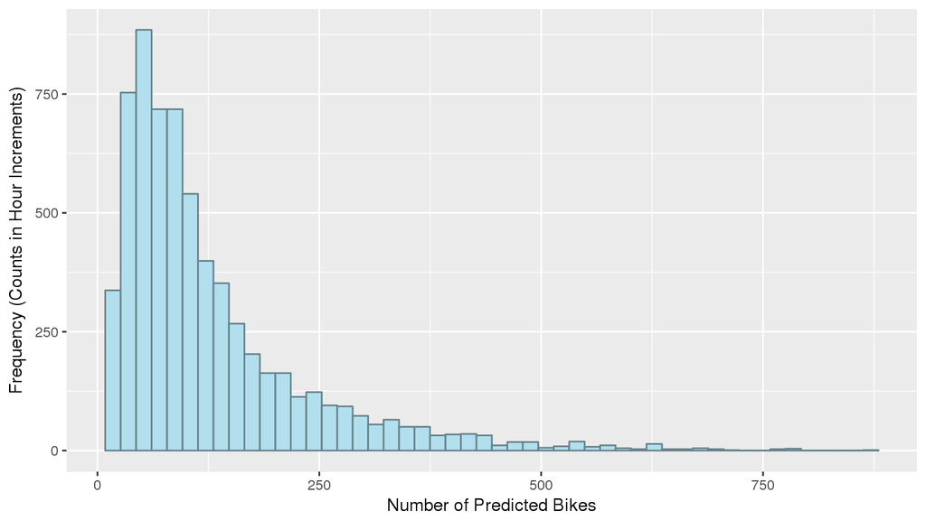

In the end, our model yielded a Kaggle score of 1.20101.